# Osteotherapy research

16 November 2020

## Introduction

Leonore en Jorrit vragen hulp bij het opzetten van een onderzoek. Het onderzoek is onderdeel van hun opleiding tot Ortho-manuele therapie. Bij het onderzoek wordt het effect gemeten van een behandelingsmethode.

Een voorbeeld hypothese.  
**H<sub>0</sub>**: De decompressie methode geeft geen genezing ten opzichte van de placebo behandeling.  
**H<sub>1</sub>**: Er is een significante relatie tussen de decompressie behandeling en genezing van de patient.

## Trial setup I

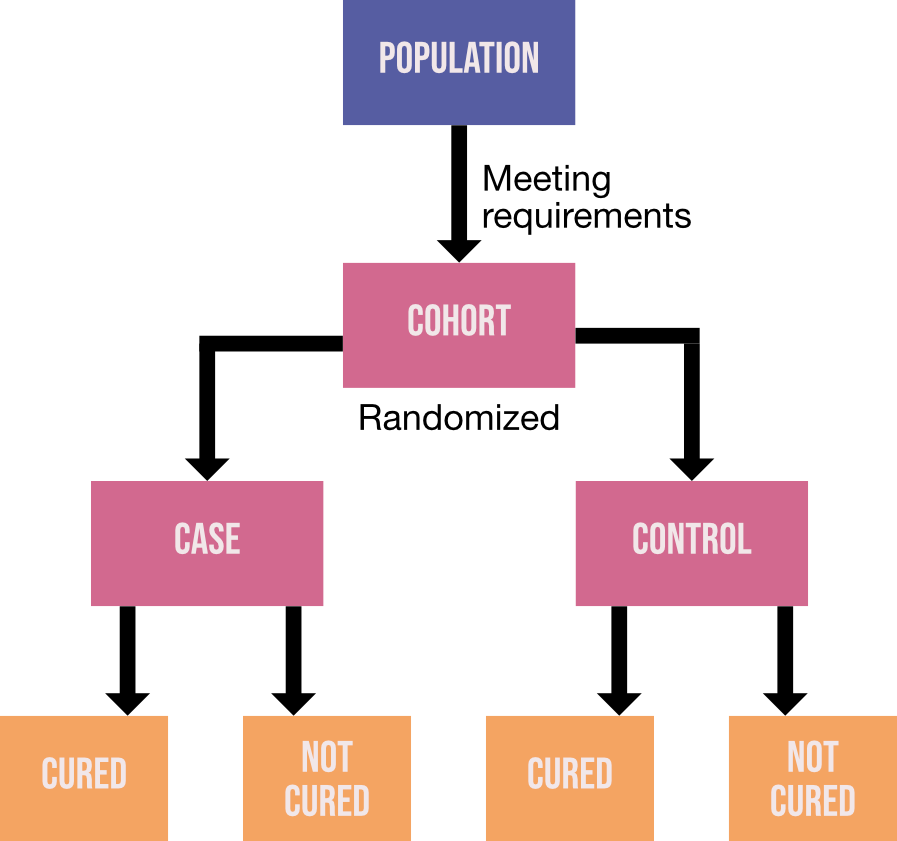

- Een steekproef van *n* subjects
- Twee groepen (echte behandeling en placebo behandeling)
- Meting van effect

## Method

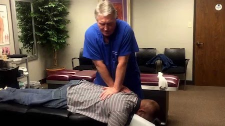

Subject meeting requirements receive:

- Manual decompression treatment
- Manual placebo treatment

## Results I

```
## # A tibble: 12 x 2
##    Treatment  Outcome
##    <chr>      <chr>
##  1 placebo    Not cured
##  2 placebo    Cured
##  3 placebo    Not cured
##  4 placebo    Not cured
##  5 placebo    Not cured
##  6 placebo    Not cured
##  7 placebo    Not cured
##  8 placebo    Cured
##  9 decompress Not cured
## 10 placebo    Not cured
## 11 placebo    Cured
## 12 placebo    Not cured
```

## Results II

Contingency table showing how many subjects were cured after receiving different treatments.

|  |  | Treatment | Placebo | **Total** |
| --- | --- | --- | --- | --- |
| Outcome? | Cured | 28 | 48 | **76** |
|  | Not cured | 10 | 114 | **124** |
|  | **Total** | **38** | **162** | **200** |

## Results III

Pearson’s Chi-square test: \(\chi^{2} = \sum \frac{(observed_{ij} - model_{ij})^{2}}{model_{ij}}\)

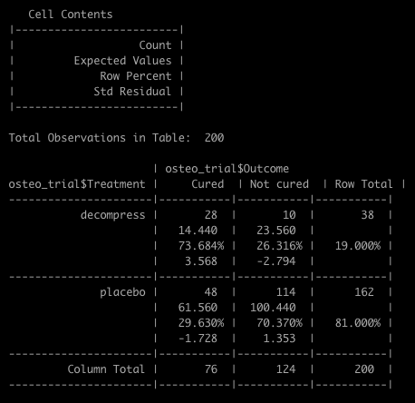

## Results IV

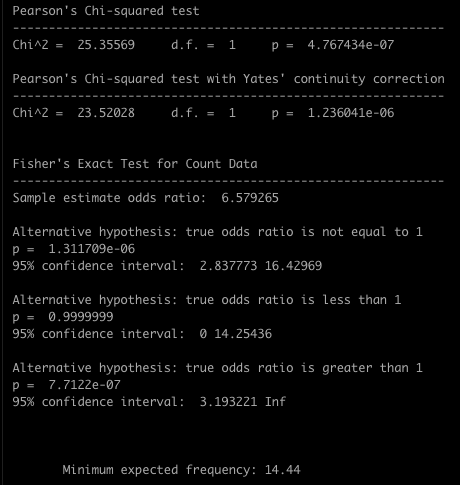

| df | p_0.05 | p_0.01 |
| --- | --- | --- |
| 1 | 3.84 | 6.63 |
| 2 | 5.99 | 9.21 |
| 3 | 7.81 | 11.34 |
| 4 | 9.49 | 13.28 |
| 5 | 11.07 | 15.09 |

## Conclusion

The value of \(\chi^{2}\) was 25.36,  
degree of freedom is **one**,  
significant at *p* < 0.001.

The **H<sub>0</sub>** is rejected.

There as a significant association between the type of treatment and whether or not the patient was cured.

## Discussion

- Cure might not be TRUE or FALSE, but more like on a scale,
- Maybe bias for gender, BMI, age, etc.